# DV 5 HW

# Chapter 5 - Data Visualization

Here, we are going to practice some of the skills emphasized in Chapter 5. At first, it may seem that a lot of the skills are similar to those we learned in Modern Dive. I have two responses to that. First, you are right; repetition is important. That’s how we learn things. Second, this chapter presents some incredibly handy tricks that as a Data Analyst you will use all the time. In these exercises, we are going to be using data from the WNCAA tournament.

As always, let’s begin by reading in the data.

```r
library(tidyverse)
# Read in the data
#| message: false
wncaa <- read_csv("https://raw.githubusercontent.com/vaiseys/dav-course/main/Data/wncaa.csv")
# Glimpse the data
glimpse(wncaa)
```

```
Rows: 2,092
Columns: 19
$ year              <dbl> 1982, 1982, 1982, 1982, 1982, 1982, 1982, 1982, 1982…
$ school            <chr> "Arizona St.", "Auburn", "Cheyney", "Clemson", "Drak…
$ seed              <dbl> 4, 7, 2, 5, 4, 6, 5, 8, 7, 7, 4, 8, 2, 1, 1, 2, 3, 6…
$ conference        <chr> "Western Collegiate", "Southeastern", "Independent",…
$ conf_w            <dbl> NA, NA, NA, 6, NA, NA, NA, NA, NA, NA, NA, NA, NA, N…
$ conf_l            <dbl> NA, NA, NA, 3, NA, NA, NA, NA, NA, NA, NA, NA, NA, N…
$ conf_percent      <dbl> NA, NA, NA, 66.7, NA, NA, NA, NA, NA, NA, NA, NA, NA…
$ conf_place        <chr> "-", "-", "-", "4th", "-", "-", "-", "-", "-", "-", …
$ reg_w             <dbl> 23, 24, 24, 20, 26, 19, 21, 14, 21, 28, 24, 17, 22, …
$ reg_l             <dbl> 6, 4, 2, 11, 6, 7, 8, 10, 8, 7, 5, 13, 7, 5, 1, 6, 4…
$ reg_percent       <dbl> 79.3, 85.7, 92.3, 64.5, 81.3, 73.1, 72.4, 58.3, 72.4…
$ how_qual          <chr> "at-large", "at-large", "at-large", "at-large", "aut…
$ x1st_game_at_home <chr> "Y", "N", "Y", "N", "Y", "N", "N", "N", "N", "N", "Y…
$ tourney_w         <dbl> 1, 0, 4, 0, 2, 0, 0, 0, 0, 0, 2, 0, 2, 1, 5, 3, 1, 1…
$ tourney_l         <dbl> 1, 1, 1, 1, 1, 1, 1, 1, 1, 1, 1, 1, 1, 1, 0, 1, 1, 1…
$ tourney_finish    <chr> "RSF", "1st", "N2nd", "1st", "RF", "1st", "1st", "1s…
$ full_w            <dbl> 24, 24, 28, 20, 28, 19, 21, 14, 21, 28, 26, 17, 24, …
$ full_l            <dbl> 7, 5, 3, 12, 7, 8, 9, 11, 9, 8, 6, 14, 8, 6, 1, 7, 5…
$ full_percent      <dbl> 77.4, 82.8, 90.3, 62.5, 80.0, 70.4, 70.0, 56.0, 70.0…
```

[output not shown]

We have data for all teams that have made it to the WNCAA tournament. We have a wealth of information from `reg_percent`, the percentage of wins in the regular season, to the place they ended in a given tournament (`tourney_finish`).

## Question 1

Let’s practice some of the summarizing skills that Healy introduces. We are going to examine the percentage of tournaments that schools have won.

First, `filter` the dataset for observations where `tourney_finish` equals `Champ`.

```r
filter_wncaa <- wncaa |>
  filter(tourney_finish == "Champ")
```

Now, use `group_by` and `summarize` to calculate the percentage of tournaments each team has.

```r
tourn_percent <- filter_wncaa |>
  group_by(school) |>
  summarise(wins = n() * 100) |>
  mutate(percentage_w = (wins/sum(wins)) * 100) |>
  mutate(percentage_w = round(percentage_w, 2)) |>
  arrange(desc(percentage_w))
```

> Hint: look at the first code chunk of the chapter.

Plot a bar plot that shows these percentages by school.

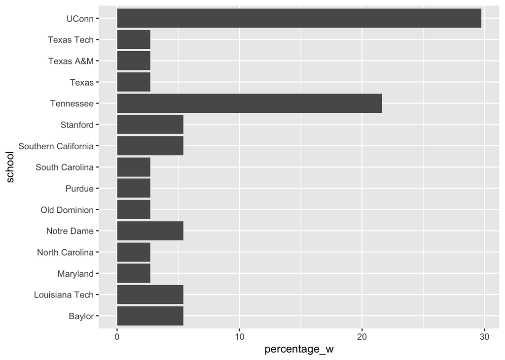

```r
ggplot(tourn_percent, aes(x = school, y = percentage_w)) +
  geom_col() +
  coord_flip()
```

What patterns do you see? Who are the two teams that have won the most?

**Answer:** I see that there are two groups of teams that have similar, if not identical, win percentages. The first group is from Texas Tech to Maryland, and the second group is from Stanford to Baylor. The two teams that have won the most are UConn and Tennessee.

## Question 2

Let’s now look at how the top teams have been seeded as they enter into the tournament. Let’s begin by creating a dataset that includes just the “top teams”. How are we going to do this? Well, let’s take the teams that show up in your bar plot above. We are going to work with the dataset that only includes teams that have ever won the tournament. I’ll show you how to do it.

```r
champ_names <- unique(filter_wncaa$school)
```

Now, we filter our original name so that only these schools are included.

```r
winners <- wncaa %>%
  filter(school %in% champ_names)
```

Now, make a plot that shows boxplots for the distribution of `seeds` for each school. Make sure you use `coord_flip()` so that the school names are legible.

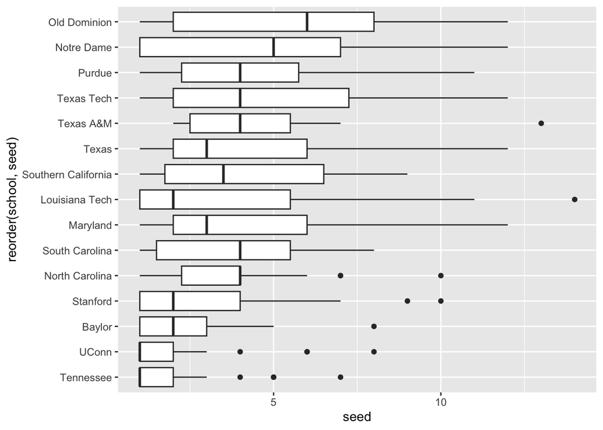

```r
ggplot(winners, aes(x = reorder(school, seed), y = seed)) +
         geom_boxplot() +
  coord_flip()
```

These days, it’s good practice to add all the data points in addition to the boxplot. You can use `geom_jitter()` to do this. Don’t forget to use `outlier.shape = NA` in the boxplot so you don’t plot the outliers twice.

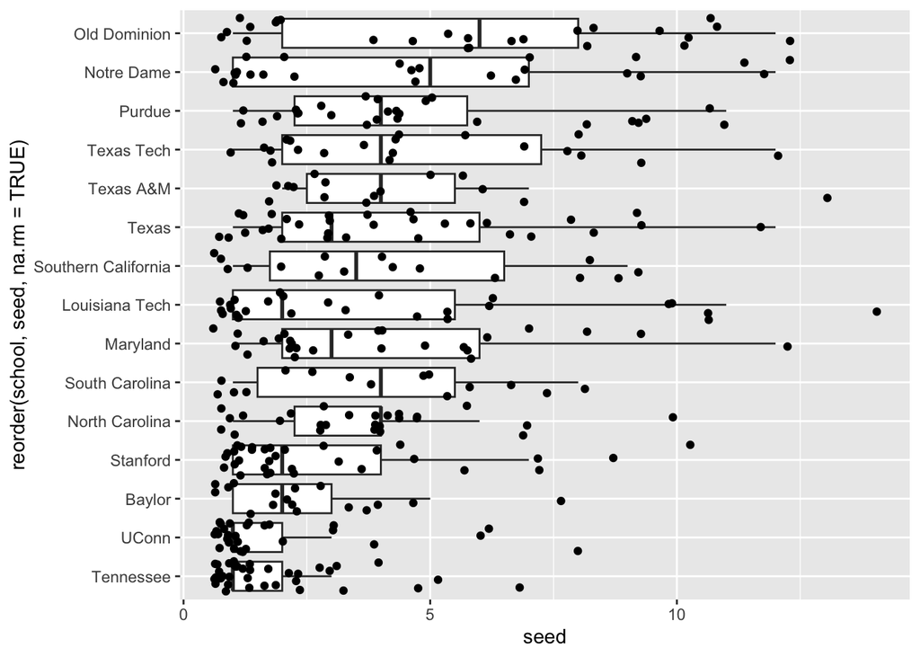

```r
ggplot(winners, aes(x = seed, y = reorder(school, seed, na.rm=TRUE))) +
         geom_boxplot(outlier.shape = NA) +
          geom_jitter()
```

We will also want to organize the plots so that they convey information more clearly. Use the `reorder()` trick to show the distributions in a an order that is easier to understand. You will need to calculate some school-specific statistics to use for the reordering. (You might find `group_by()` and `mutate()` valuable here, although there are several ways to do this.)

Describe the results? Any surprises?

**Answer:**

Tennessee and UConn had the highest seedings in comparison to the other teams. I was surprised UConn was not higher than Tennessee considering they had a higher percentage of tournament wins.

Try to make the same plot using `geom_violin()` instead of `geom_boxplot()`. Which visualization do you think is more informative? There’s no right answer here but provide some reasoning to justify your choice.

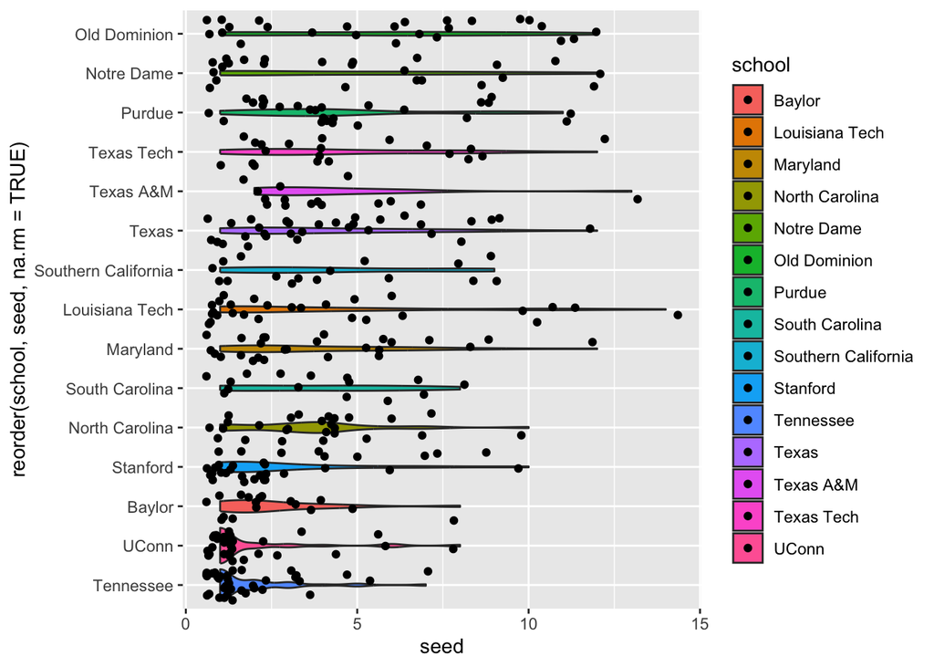

```r
ggplot(winners, aes(x = seed, y = reorder(school, seed, na.rm=TRUE), fill = school)) +
  geom_violin(outlier.shape = NA)+
  geom_jitter()
```

**Answer:**

## Question 3

Try making the plot above but using `geom_point` only. Why does it not work very well?

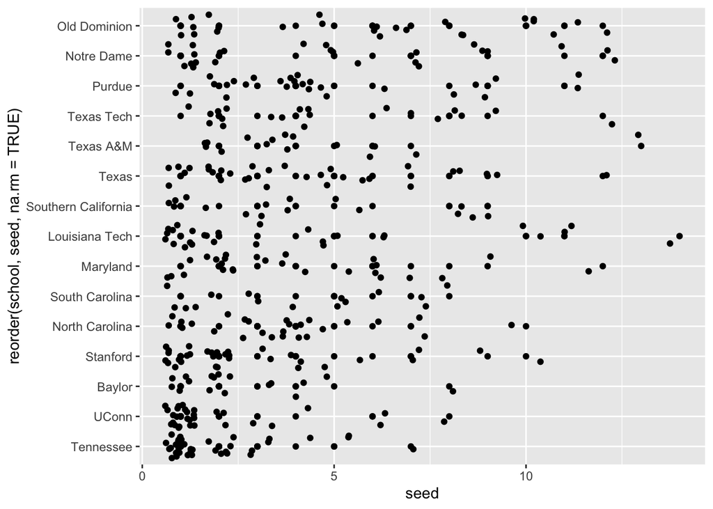

```r
ggplot(winners, aes(x = seed, y = reorder(school, seed, na.rm=TRUE))) +
  geom_point(outlier.shape = NA) +
  geom_jitter()
```

**Answer:**

This does not work as well because there are data points on top of one another, so it is hard to interpret certain aspects of the data like average seeds for each school.

## Question 4

Okay, now let’s try the `summarize_if()` verb. Let’s make a new data frame by taking the `winners` dataset, grouping by school, and take the `mean()` and `sd()` of the columns **if** they are numeric. HINT: you can also use the newer `across()` syntax for this if you prefer. It looks like this:

```r
winners_mean_sd <- winners |>
  group_by(school) |>
  summarize(across(where(is.numeric),
                   list(mean = mean,
                        sd = sd)))
```

Let’s explore the average win percentage of these schools across the seasons. In your new dataset, this column should be called `reg_percent_mean`. Make a dot plot, where this column is in the y-axis and school is the x-axis. Again, use our tricks, `coord_flip` and `reorder` to make the plot legible. (Or you can specify the proper axes from the start if you like. Sometimes this is easier, but not always!)

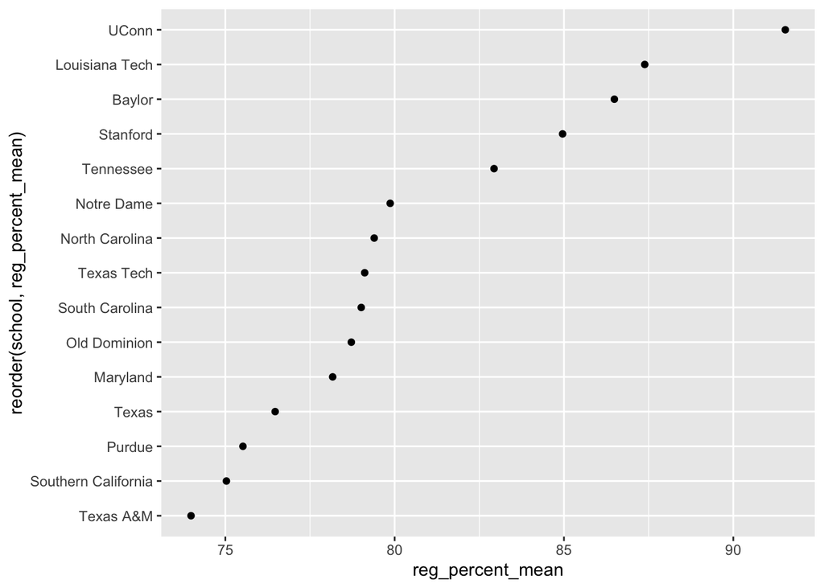

```r
ggplot(winners_mean_sd, aes(x = reorder(school, reg_percent_mean), y = reg_percent_mean)) +
  geom_point() +
  coord_flip()
```

Describe the results. Which tournament winner had the lowest regular season win percentage?

**Answer:**

UConn had the highest win percentage by far in comparison to the other schools, with Louisiana Tech is a distant second. Texas A&M was the tournament winner that had the lowest regular season win percentage.

Now, let’s try to take into account the standard deviation. Use the `geom_pointrange` to show the intervals of one standard deviation below and above the mean (just like Figure 5.15 in the online version of socviz.co).

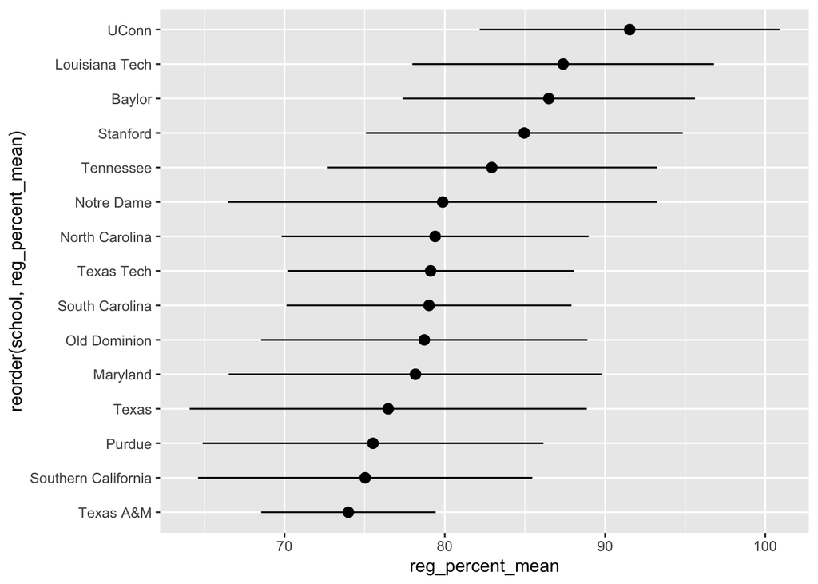

```r
ggplot(winners_mean_sd, aes(x = reorder(school, reg_percent_mean), y = reg_percent_mean)) +
  geom_pointrange(aes(ymin = reg_percent_mean - reg_percent_sd,
                      ymax = reg_percent_mean + reg_percent_sd)) +
  coord_flip()
```

What is the school with the narrowest interval? What does this mean?

**Answer:**

The school with the narrowest interval is Texas A&M. This means the school’s win percentages each season were the closest to their average win percentage in comparison to the other schools.

Can you make the same plot using `geom_linerange` ? Do you think this is a good or bad idea? Why? There is no right answer; just give your reasoning.

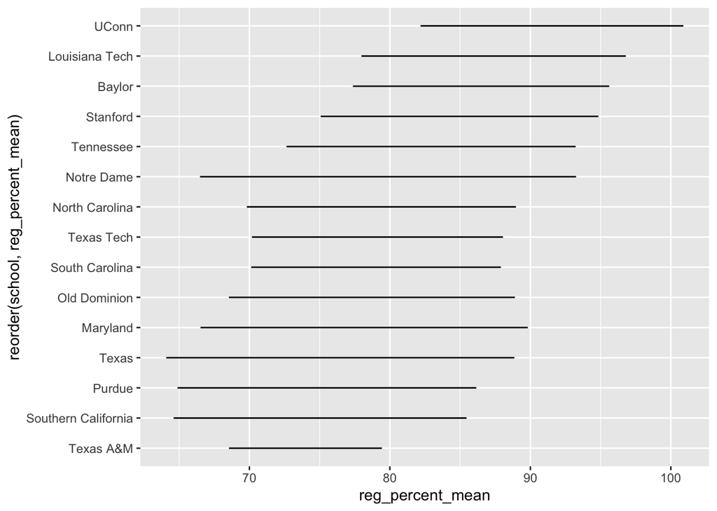

```r
ggplot(winners_mean_sd, aes(x = reorder(school, reg_percent_mean), y = reg_percent_mean)) + geom_linerange(aes(ymin = reg_percent_mean - reg_percent_sd,                                            ymax = reg_percent_mean + reg_percent_sd))+
  coord_flip()
```

**Answer:**

I think is a bad idea because there is no way for me to see the average (mean) win percentage, which is not helpful for best understanding the data.